[figure not shown]

# Assessment Unit Summary

Assessment units, identified by assessment unit ID (AU ID), are entire waterbodies or portions of them located within a specified drainage area. These drainage areas, also known as watersheds, are identified by hydrologic unit codes (HUCs). Water quality data collected within assessment units are obtained during a public call for data and analyzed using pre-defined methods. These data help us determine if state waters are meeting Alaska water quality standards. After this analysis is completed, waterbodies are placed in corresponding categories (see definitions below).

This Marine Assessment Unit is 466.133 square miles and is located in the HUC1905010420 watershed.

| AU ID: | AK_M_5010420_000 |
| --- | --- |
| AU Name: | Safety Sound-Frontal Norton Sound |
| AU Type: | Marine |
| Overall Category: | Not enough information |

[interactive chart not shown]

### Monitoring Location(s) Summary

| Monitoring Location | Latitude | Longitude |
| --- | --- | --- |
| AKDECWQ-NME05_HSLP | 64.48048 | -165.2979 |
| AKDECWQ-NME06_HSLP | 64.45842 | -165.4774 |

### Designated Uses and Attainment

| Use: | Use Category: |
| --- | --- |
| GROWTH AND PROPAGATION OF FISH, SHELLFISH, OTHER AQUATIC LIFE AND WILDLIFE | 3 |
| HARVESTING FOR CONSUMPTION OF RAW MOLLUSKS OR OTHER RAW AQUATIC LIFE | 3 |
| WATER RECREATION | 3 |
| WATER SUPPLY | 3 |

###### **Categories 1 and 2:** Waters for which there is enough information to determine that water quality standards are attained for all or some of their designated uses.

###### **Category 3:** Waters for which there is not enough information to determine their status.

###### **Category 4:** Waters that are impaired, but have one of several different types of waterbody recovery plans.

###### **Category 5:** Waters that are impaired and do not yet have waterbody recovery plans. Also known as 303(d) list impaired waters.

### Attainment by Parameter

[output not shown]

###### **Parameter:** Qualitative or quantitative measurements of physical, chemical, or biological attributes such as temperatures, metals, or bacteria.

###### **Designated Use:** Water quality goals of a waterbody or portion thereof, in part, by designating the use or uses to be made of the water.

###### **Attainment:** Achieving attainment means that a waterbody is supporting all designated uses for the pollutant parameters evaluated.

### Distribution of Parameters

The following figures depict the range of each sampled parameter at this Assessment Unit. The actual sample values are overlaid onto the boxplots to provide an additional visualization of the spread. Samples originating from different Monitoring Locations are assigned different colors.

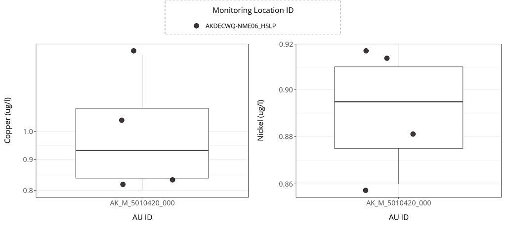

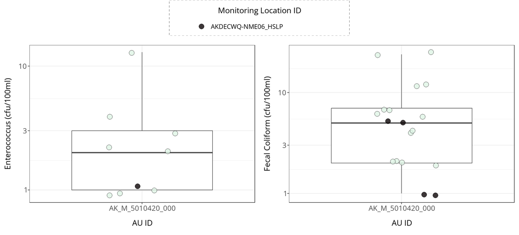

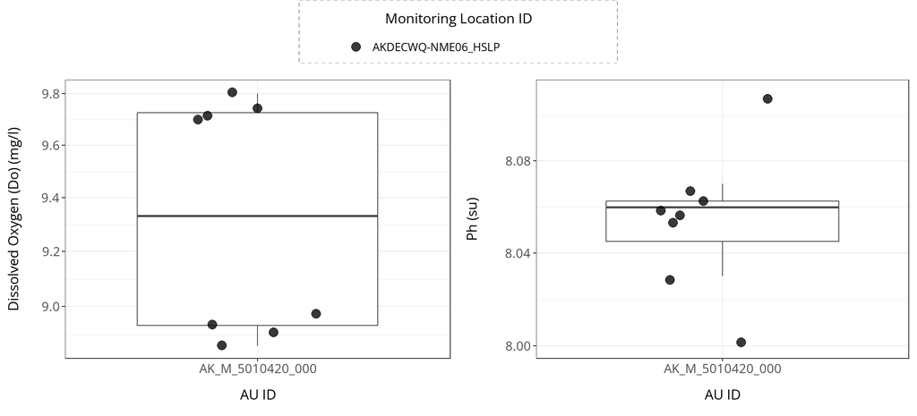

[figure not shown]

### Parameter Specific Time Series

The following figures depict the range of results over time in this Assessment Unit. Samples originating from different Monitoring Locations are assigned different colors. This is a simple time series plot used for visualization purposes and should not be used to determine water quality trends.

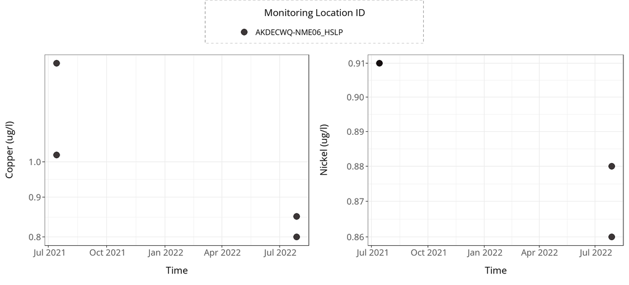

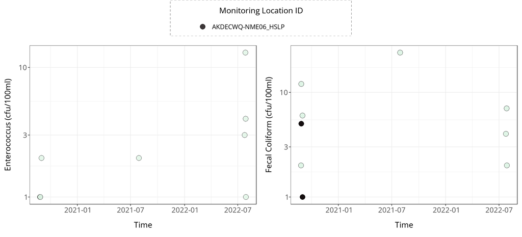

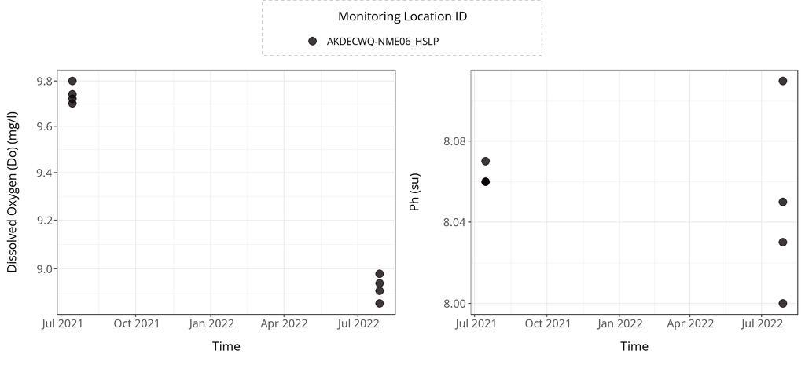

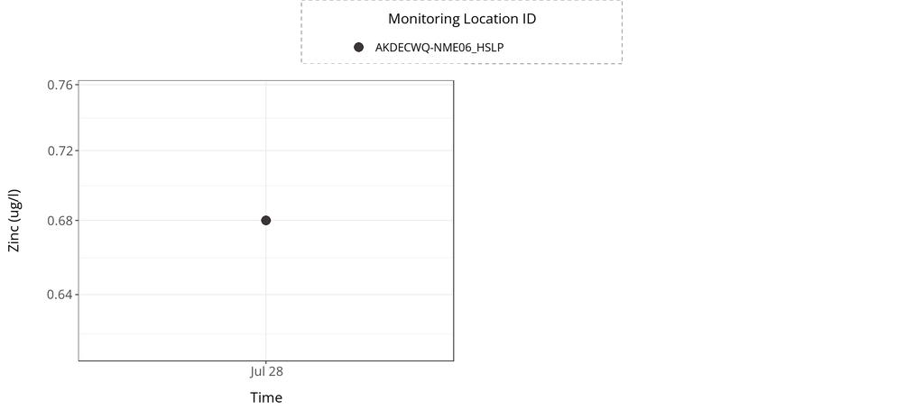